# [Lecture Note] Repetition Structures

- Show All Code
- Hide All Code
- View Source

MGS3001 Python Programming for Business, Spring 2025

Author

Chad (Chungil Chae)

Published

Tue, 27 May 2025

# Learning Objectives

- Introduction to Repetition Structures
- The while Loop: A Condition-Controlled Loop
- The for Loop: A Count-Controlled Loop
- Calculating a Running Total
- Sentinels
- Input Validation Loops
- Nested Loops
- Turtle Graphics: Using Loops to Draw Designs

## SHORT VIDEO INTRODUCTION

[video not shown]

# Introduction to Repetition Structures

A repetition structure causes a statement or set of statements to execute repeatedly

```python
# Get a salesperson's sales and commission rate.
sales = float(input('Enter the amount of sales: '))
comm_rate = float(input('Enter the commission rate: '))
# Calculate the commission.
commission = sales * comm_rate
# Display the commission.
print('The commission is $', format(commission, ',.2f'), sep='')
# Get another salesperson's sales and commission rate.
sales = float(input('Enter the amount of sales: '))
comm_rate = float(input('Enter the commission rate: '))
# Calculate the commission.
commission = sales * comm_rate
# Display the commission.
print('The commission is $', format(commission, ',.2f'), sep='')
# Get another salesperson's sales and commission rate.
sales = float(input('Enter the amount of sales: '))
comm_rate = float(input('Enter the commission rate: '))
# Calculate the commission.
commission = sales * comm_rate
# Display the commission.
print('The commission is $', format(commission, ',.2f'), sep='')
# And this code goes on and on ...
```

- Programmers commonly have to write code that performs the same task over and over.
- For example, suppose you have been asked to write a program that calculates a 10 percent sales commission for several salespeople.
- Although it would not be a good design, one approach would be to write the code to calculate one salesperson’s commission, and then repeat that code for each salesperson.

> One long sequence structure containing a lot of duplicated code.
- Disadvantages to this approach
  - The duplicated code makes the program large.
  - Writing a long sequence of statements can be time consuming.
  - If part of the duplicated code has to be corrected or changed, then the correction or change has to be done many times.
- Instead of writing the same sequence of statements over and over
  - A better way to repeatedly perform an operation is to write the code for the operation once
  - then place that code in a structure that makes the computer repeat it as many times as necessary.

> This can be done with a repetition structure, which is more commonly known as a loop.

## Condition-Controlled and Count-Controlled Loops

- Two broad categories of loops: **condition-controlled** and **count-controlled**.
  - **A condition-controlled loop** uses a true/false condition to control the number of times that it repeats.
  - **A count-controlled loop** repeats a specific number of times.

**while statement**

In Python, you use the while statement to write a condition-controlled loop, and you use the for statement to write a count-controlled loop.

# The while Loop: A Condition-Controlled Loop

A condition-controlled loop causes a statement or set of statements to repeat as long as a condition is true. In Python, you use the while statement to write a condition-controlled loop.

- The while loop gets its name from the way it works: while a condition is true, do some task. The loop has two parts:
  - 1. a condition that is tested for a true or false value, and
  - 2. a statement or set of statements that is repeated as long as the condition is true.

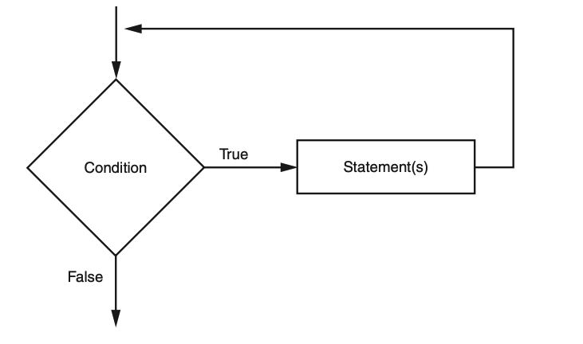

- Notice what happens if
  - the condition is true:
    - one or more statements are executed, and the program’s execution flows back to the point just above the diamond symbol.
  - The condition is tested again, and if it is true,
    - the process repeats.
  - If the condition is false,
    - the program exits the loop.

```python
while condition:
  statement
  statement
  etc.
```

- The while clause begins with the word while, followed by a Boolean condition that will be evaluated as either true or false.
- A colon appears after the condition.
- Beginning at the next line is a block of statements.
- When the while loop executes, the condition is tested.
  - If the condition is true,
    - the statements that appear in the block following the while clause are executed, and the loop starts over.
  - If the condition is false,
    - the program exits the loop.

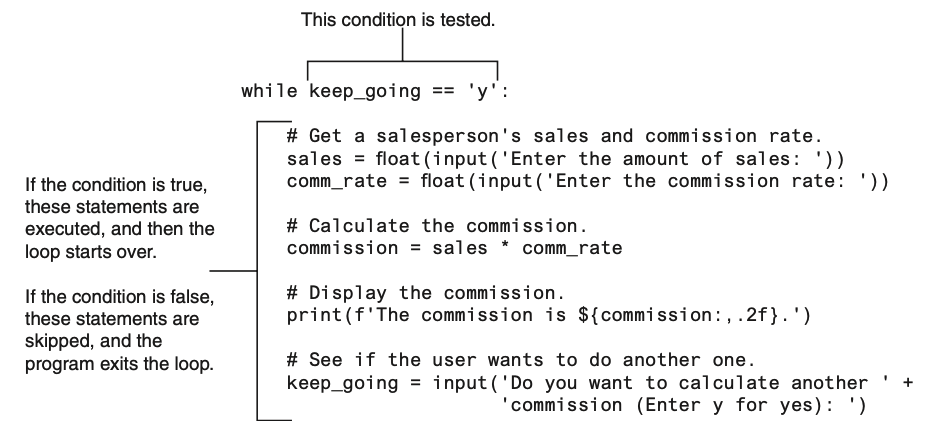

- In order to stop executing, inside the loop to make the expression keep_going == ‘y’ false.
  - “Do you want to calculate another commission (Enter y for yes).”
  - If the user enters y (and it must be a lowercase y),
    - Then the expression keep_going == ‘y’ will be true when the loop starts over.
    - This will cause the statements in the body of the loop to execute again.
  - But if the user enters anything other than lowercase y,
  - The expression will be false when the loop starts over, and the program will exit the loop.

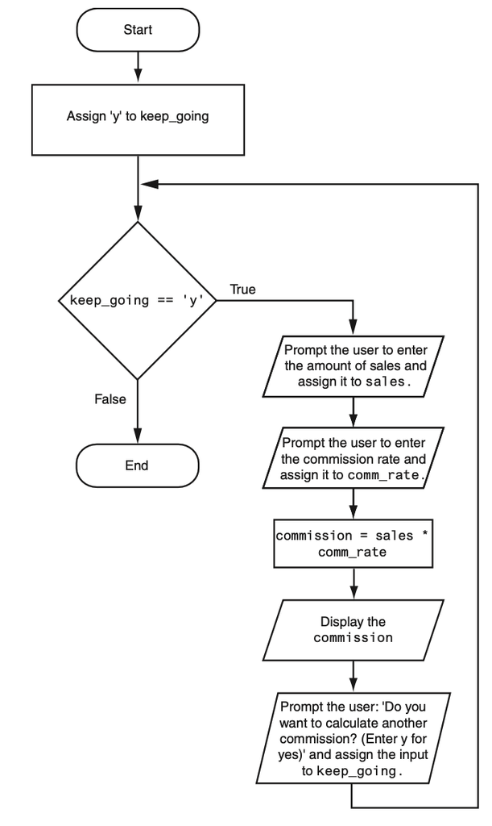

## The while Loop Is a Pretest Loop

- The while loop is known as a pretest loop,
  - Which means it tests its condition before performing an iteration.
  - Because the test is done at the beginning of the loop

```python
while keep_going == 'y':
```

- The loop will perform an iteration only if the expression keep_going ==‘y’ is true.
- This means that
  - 1. the keep_going variable has to exist, and
  - 2. it has to reference the value ‘y’.

To make sure the expression is true the first time that the loop executes, we assigned the value ‘y’ to the keep_going variable

```python
keep_going = 'y'
```

- By performing this step we know that the condition keep_going ==‘y’ will be true the first time the loop executes.
- This is an important characteristic of the while loop:
  - it will never execute if its condition is false to start with.
  - In some programs, this is exactly what you want.

## Infinite Loops

- Something inside the loop must eventually make the test condition false.
- If a loop does not have a way of stopping, it is called an **infinite loop**.
  - An infinite loop continues to repeat until the program is interrupted.
  - Infinite loops usually occur when the programmer forgets to write code inside the loop that makes the test condition false.
  - In most circumstances, you should avoid writing infinite loops.
  - As a consequence, the loop has no way of stopping. (The only way to stop this program is to press Ctrl+C on the keyboard to interrupt it.)

```python
# code_04_03_infinite.py
# This program demonstrates an infinite loop.
# Create a variable to control the loop.
keep_going = 'y'

# Warning! Infinite loop!
while keep_going == 'y':
    # Get a salesperson's sales and commission rate.
    sales = float(input('Enter the amount of sales: '))
    comm_rate = float(input('Enter the commission rate: '))

    # Calculate the commission.
    commission = sales * comm_rate
    # Display the commission.
    print('The commission is $', format(commission, ',.2f'), sep='')
```

# The for Loop: A Count-Controlled Loop

A count-controlled loop iterates a specific number of times. In Python, you use the for statement to write a count-controlled loop.

- A count-controlled loop iterates a specific number of times.
- Count-controlled loops are commonly used in programs.
  - For example, Each time the loop iterates, it will prompt the user to enter the sales for one day.
  - You use the for statement to write a count-controlled loop.
- In Python, the for statement is designed to work with a sequence of data items.
- When the statement executes, it iterates once for each item in the sequence.

```python
for variable in [value1, value2, etc.]:
  statement
  statement
  etc.
```

**1**

for clause

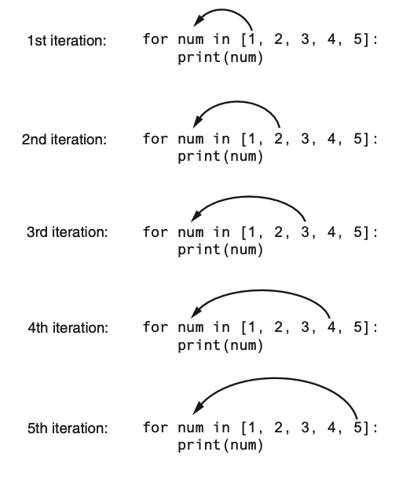

- Python programmers commonly refer to the variable that is used in the for clause as the target variable because it is the target of an assignment at the beginning of each loop iteration.
- The values that appear in the list do not have to be a consecutively ordered series of numbers.
  - For example, next program uses a for loop to display a list of odd numbers.
  - There are five numbers in the list, so the loop iterates five times.

```python
# code_04_05_simple_loop2.py
print('I will display the odd numbers 1 through 9.')
for num in [1, 3, 5, 7, 9]:
    print(num)
```

```python
# code_04_06_simple_loop3.py
# This program also demonstrates a simple for
# loop that uses a list of strings.

for name in ['Winken', 'Blinken', 'Nod']:
    print(name)
```